# Получение и первичное исследование данных

# (EDA, exploratory data analyze)

Курс "Модели и методы интеллектуального анализа данных"

Чернышов Ю.Ю., к.ф.-м.н., доцент кафедры "ИТЗИ"

УрГУПС, 2020

# Содержание лекции

Для работы с данными нужны сами данные :-) Большинство рабочего времени специалиста по работе с данными уходит на получение, очистку, преобразование, предварительное исследование данных. От качества этой предварительной работы зависит качество, скорость, результативность работы моделей, использующих данные (Garbage-In-Garbage-Out).

В лекции рассмотрены источники (способы) получения данных и инструменты предварительного (разведочного) анализа данных.

## Способы (источники) получения данных

Самый нерациональный (но тем не менее часто применяющийся и в настоящее время) способ создания данных - ручное внесение информации (заполнение таблиц, создание отчетов, "набивалки"). Однако все чаще появляются проекты с автоматизированным и унифицированным способом сбора, хранения, преобразования данных (что гораздо эффективнее). Рассмотрим некоторые из них.

1. Текстовые файлы
2. xml
3. API, JSON
4. Базы данных
5. OLAP-кубы
6. Другие источники: результаты измерений, IoT, Twitter, социальные сети

Кроме того, создано множество наборов данных (dataset), применяющихся как для обучения, так и для глобальных исследований

1. Датасеты kaggle (kaggle.com)
2. Датасеты sklearn

## Текстовые файлы

Чтение и запись из текстового файла. Файл необходимо открыть в соответствующем режиме ('r' - read/чтение, 'w' - write/запись, 'a' - append/добавление)

```python
with open('data.txt', 'w') as f: f.write('1,2,3\n')
f.close()
with open('data.txt', 'r') as f: s = f.read()
f.close()
print(s, end="")
```

```
1,2,3
```

csv - текстовые файлы специального вида, данные разделены специальным символом, чаще всего запятой (comma separated value).

```python
with open('data.txt', 'a') as f: f.write('5,6,7\n')
f.close()
df = pd.read_csv('data.txt', names="ABC")
display(df)
```

|  | A | B | C |
| --- | --- | --- | --- |
| 0 | 1 | 2 | 3 |
| 1 | 5 | 6 | 7 |

Назад к Оглавлению

## xml

xml (extensible markup language) - язык разметки данных с использованием специальный блоков, обозначаемых тегами. Пример xml файла:

<?xml version="1.0" ?> <Appointments> <appointment> <begin>1181251680</begin> <uid>040000008200E000</uid> <alarmTime>1181572063</alarmTime> </appointment> </Appointments>

Существуют различные стандартные билиотеки для работы с xml, например, в Python это minidom, ElementTree, BeautifulSoap

Назад к Оглавлению

## API, JSON

Объектная нотация JavaScript Object Notation используется при сериализации (преобразованию к виду, похожему на словарь).

```python
import json
d = {'personal data': {
                        'surname': 'Ivanov',
                        'name': 'Ivan'
                    },
    'age': 42, 'height': 171, 'weight': 80}
print(d)
s = json.dumps(d)
print(s)
d = json.loads(s)
print(d)
```

```
{'personal data': {'surname': 'Ivanov', 'name': 'Ivan'}, 'age': 42, 'height': 171, 'weight': 80}
{"personal data": {"surname": "Ivanov", "name": "Ivan"}, "age": 42, "height": 171, "weight": 80}
{'personal data': {'surname': 'Ivanov', 'name': 'Ivan'}, 'age': 42, 'height': 171, 'weight': 80}
```

Экспортируем данные из открытого API github.com

```python
import requests
endpoint = 'https://api.github.com/users/yurichernyshov/repos'
repos = json.loads(requests.get(endpoint).text)
for elem in repos:
    print(elem['name'])
```

```
BlogNote
Data-Science-Course-USURT
Games
github-slideshow
Information-Systems-Course-USURT
Kaggle_Titanic
```

Назад к Оглавлению

## Базы данных

Стандартным источником информации в системах, работающих продуктивной среде, являются базы данных - хранилища большого объема информации. В зависимости от прикладных задач для хранения данных может быть выбрана соответствующая база данных. Для работы с базами данных используют SQL запросы.

Примеры SQL запросов

SELECT model, speed, hd from PC WHERE price<500

select model,price from Printer WHERE price=(SELECT MAX(price) from Printer)

SELECT DISTINCT Product.type, Laptop.model, Laptop.speed FROM Product JOIN Laptop ON Laptop.model=Product.model WHERE speed < ANY (SELECT MIN(speed) FROM PC)

Назад к Оглавлению

## Стандартные, заранее подготовленные данные

Существует большое количество созданных наборов данных (называемых датасетами, datasets), предназначенными как для тренировок, так и для решения прикладных задач.

Ресурс https://www.kaggle.com/datasets содержит большое количество данных, один из критериев оценки участников сообщества kaggle - оценка размещенных участниками датасетов. Содержит как тренировочные данные, так и данные для решения глобальных задач (предсказание объема продаж Walmart, предсказание динамики распространения коронавируса)

В библиотеке sklearn в специальном модуле sklearn.datasets содержится большое количество тренировочных датасетов.

```python
from sklearn.datasets import make_friedman1
X, y = make_friedman1(n_samples=50, n_features=10, random_state=0)
print(len(X), len(X[0]))
```

```
50 10
```

Назад к Оглавлению

## Другие источники: результаты измерений, IoT, Twitter, социальные сети

Через открытые источники можно получать информацию для анализа из социальных сетей, twitter и т.п.

Перечень популярных API (например, прогноз погоды, фильмы, финансовый анализ) для Python можно найти здесь: https://rapidapi.com/collection/list-of-python-apis

Назад к Оглавлению

# Разведочный анализ данных

## Инструменты

1. Системы бизнес-аналитики BI
2. Различные математические пакеты программ: Statistica, MathCad, Maple,...
3. Встроенные инструменты фреймворков (PostgreSQL, Oracle)
4. Excel
5. Python (pandas, matplotlib, numpy, sklearn)

## Этапы разведочного анализа данных

1. Предварительное изучение данных: правильность получения, природа, целостность, актуальность, адекватность
2. Выявление в данных взаимосвязей, кластеров
3. Анализ аномалий - причина, повторяемость, угроза для выборки
4. Прореживание данных - выявление наиболее актуальных параметров
5. Проверка основных гипотез
6. Разработка и применение начальных простых моделей

### Предварительное изучение данных: правильность получения, природа, целостность, актуальность, адекватность

| 29 декабря 2019 | Иванов И.И. | 14.01 |
| --- | --- | --- |
| 29 декабря 1019 | Иванов Ваня | 12,02 |
| 31 февраля 2020 |  | 14 |
| 01 апреля 2020 | Петров П.П. | -100 |

### Выявление в данных взаимосвязей, кластеров

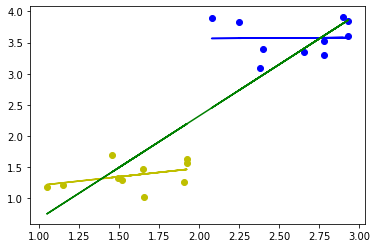

```python
Yellows = [[xi+1 for xi in np.random.rand(10)],[yi+1 for yi in np.random.rand(10)]]
Blues   = [[xi+2 for xi in np.random.rand(10)],[yi+3 for yi in np.random.rand(10)]]
Greens = [Yellows[0]+Blues[0], Yellows[1]+Blues[1]]
plt.scatter(Yellows[0], Yellows[1],color="y")
plt.scatter(Blues[0],   Blues[1],color="b")
model = LinearRegression()

model.fit(np.array(Blues[0]).reshape(-1,1), Blues[1])
plt.plot(Blues[0], model.predict(np.array(Blues[0]).reshape(-1,1)), color="b")
model.fit(np.array(Yellows[0]).reshape(-1,1), Yellows[1])
plt.plot(Yellows[0], model.predict(np.array(Yellows[0]).reshape(-1,1)), color="y")
model.fit(np.array(Greens[0]).reshape(-1,1), Greens[1])
plt.plot(Greens[0], model.predict(np.array(Greens[0]).reshape(-1,1)), color="g")
plt.show()
```

### Прореживание данных - выявление наиболее актуальных параметров

1. Уменьшение количества параметров
2. Метод главных компонент

### Проверка основных гипотез

1. Критерий Пирсона
2. Проверка законов распределения
3. A/B тестирование

### Предварительное изучение данных

1. Получить данные (создать pd.DataFrame)
- Файлы: `pd.read_csv()`, `pd.read_xls()`
- API
- xml, html, JSON
2. Провести предварительный анализ
- df.info(), df.shape(), df.columns()
- df.describe(), df.describe(include=['object', 'bool'])
- df.value_counts() для типов Categorical и Boolean
- df.sort_values(by='Total day charge', ascending=False).head()
- df[df['Churn'] == 1].mean()
- groupby, crosstab, pivot_table

### Получение данных

```python
import pandas as pd
import numpy as np
import seaborn as sb
num=5
df = pd.DataFrame({
        'Date': pd.Timestamp('20130102'),
        'Visitors': np.random.randint(0,100, num),
        'Income': np.array([100*np.random.random() for _ in range(num)]),
        'Type': pd.Categorical([np.random.choice(['Regular', 'Unique', '']) for _ in range(num)]),
        'Par1': np.array([np.random.choice(range(-10,10)) if i%2 else np.NaN for i in range(num)])
                  })
df
```

|  | Date | Visitors | Income | Type | Par1 |
| --- | --- | --- | --- | --- | --- |
| 0 | 2013-01-02 | 94 | 60.106613 | Unique | NaN |
| 1 | 2013-01-02 | 50 | 0.139812 | Unique | 8.0 |
| 2 | 2013-01-02 | 33 | 36.519272 |  | NaN |
| 3 | 2013-01-02 | 33 | 7.614536 |  | 4.0 |
| 4 | 2013-01-02 | 23 | 86.961643 | Unique | NaN |

```python
df.head(2)
```

|  | Date | Visitors | Income | Type | Par1 |
| --- | --- | --- | --- | --- | --- |
| 0 | 2013-01-02 | 94 | 60.106613 | Unique | NaN |
| 1 | 2013-01-02 | 50 | 0.139812 | Unique | 8.0 |

```python
df.tail(1)
```

|  | Date | Visitors | Income | Type | Par1 |
| --- | --- | --- | --- | --- | --- |
| 4 | 2013-01-02 | 23 | 86.961643 | Unique | NaN |

```python
print("df.shape: {}, rows: {}, columns: {}".format(df.shape, df.shape[0], df.shape[1]))
```

```
df.shape: (5, 5), rows: 5, columns: 5
```

### Типы данных, пропущенные значения

```python
df.info()
```

```
<class 'pandas.core.frame.DataFrame'>
RangeIndex: 5 entries, 0 to 4
Data columns (total 5 columns):
Date        5 non-null datetime64[ns]
Visitors    5 non-null int32
Income      5 non-null float64
Type        5 non-null category
Par1        2 non-null float64
dtypes: category(1), datetime64[ns](1), float64(2), int32(1)
memory usage: 265.0 bytes
```

```python
print(df.columns)
for vColName in df.columns[1::2]:
    print("----{}----: \n{}".format(vColName, df[vColName].value_counts()))
```

```
Index(['Date', 'Visitors', 'Income', 'Type', 'Par1'], dtype='object')
----Visitors----:
33    2
23    1
94    1
50    1
Name: Visitors, dtype: int64
----Type----:
Unique    3
          2
Name: Type, dtype: int64
```

```python
print(df.columns)
for vColName in df.columns[1::2]:
    print("{}: {}".format(vColName, df[vColName].unique()))
```

```
Index(['Date', 'Visitors', 'Income', 'Type', 'Par1'], dtype='object')
Visitors: [94 50 33 23]
Type: [Unique, ]
Categories (2, object): [Unique, ]
```

### Статистическая информация

```python
df
```

|  | Date | Visitors | Income | Type | Par1 |
| --- | --- | --- | --- | --- | --- |
| 0 | 2013-01-02 | 94 | 60.106613 | Unique | NaN |
| 1 | 2013-01-02 | 50 | 0.139812 | Unique | 8.0 |
| 2 | 2013-01-02 | 33 | 36.519272 |  | NaN |
| 3 | 2013-01-02 | 33 | 7.614536 |  | 4.0 |
| 4 | 2013-01-02 | 23 | 86.961643 | Unique | NaN |

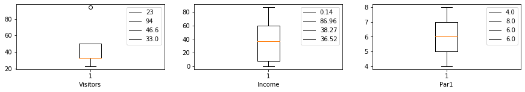

```python
from matplotlib import pyplot as plt
fig,ax=plt.subplots(1,3)
fig.set_figwidth(15)
fig.set_figheight(2)
for i, vColName in enumerate(['Visitors', 'Income','Par1']):
    ax[i].boxplot(df[vColName].dropna())
    ax[i].set_xlabel(vColName)
    ax[i].legend([round(f(df[vColName].dropna()),2) for f in [min,max,np.mean,np.median]],loc=1)
plt.show()
```

```python
df.describe()
```

|  | Visitors | Income | Par1 |
| --- | --- | --- | --- |
| count | 5.000000 | 5.000000 | 2.000000 |
| mean | 46.600000 | 38.268375 | 6.000000 |
| std | 28.218788 | 36.209279 | 2.828427 |
| min | 23.000000 | 0.139812 | 4.000000 |
| 25% | 33.000000 | 7.614536 | 5.000000 |
| 50% | 33.000000 | 36.519272 | 6.000000 |
| 75% | 50.000000 | 60.106613 | 7.000000 |
| max | 94.000000 | 86.961643 | 8.000000 |

```python
print(df.groupby('Type')['Visitors'].sum())
print(df.groupby('Type')['Income'].sum())
```

```
Type
           66
Unique    167
Name: Visitors, dtype: int32
Type
           44.133808
Unique    147.208069
Name: Income, dtype: float64
```

```python
df.groupby(['Type','Income'])['Income'].count().unstack().fillna(0)
```

| Income Type | 0.139812 | 7.614536 | 36.519272 | 60.106613 | 86.961643 |
| --- | --- | --- | --- | --- | --- |
|  | 0.0 | 1.0 | 1.0 | 0.0 | 0.0 |
| Unique | 1.0 | 0.0 | 0.0 | 1.0 | 1.0 |

```python
pd.crosstab(df['Type'], df['Income'])
```

| Income Type | 0.139812 | 7.614536 | 36.519272 | 60.106613 | 86.961643 |
| --- | --- | --- | --- | --- | --- |
|  | 0 | 1 | 1 | 0 | 0 |
| Unique | 1 | 0 | 0 | 1 | 1 |

```python
df.pivot_table(index='Income', columns='Type', aggfunc={'Type':len}, fill_value=0)
```

| Type Income | Type | Type Unique |
| --- | --- | --- |
| 0.139812 | 0 | 1 |
| 7.614536 | 1 | 0 |
| 36.519272 | 1 | 0 |
| 60.106613 | 0 | 1 |
| 86.961643 | 0 | 1 |

Назад к Этапы

### Выявление в данных взаимосвязей, кластеров

```python
df.corr()
```

|  | Visitors | Income | Par1 |
| --- | --- | --- | --- |
| Visitors | 1.000000 | 0.048204 | 1.0 |
| Income | 0.048204 | 1.000000 | -1.0 |
| Par1 | 1.000000 | -1.000000 | 1.0 |

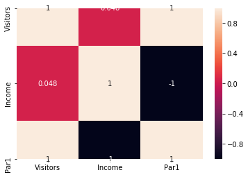

```python
sb.heatmap(df.corr(),annot=True)
```

Назад к Этапы

### Анализ аномалий - причина, повторяемость, угроза для выборки

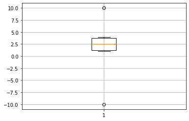

```python
x = [1,2,3,4,-10,10]
plt.boxplot(x)
plt.grid(True)
plt.show()
```

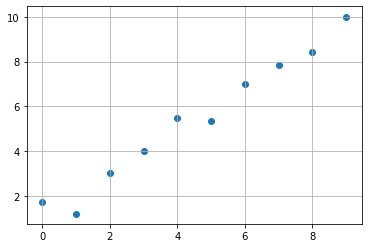

```python
x = list(range(10))
y = [x[i]+2*np.random.random() for i in range(10)]
plt.grid(True)
plt.scatter(x,y)
plt.show()
```

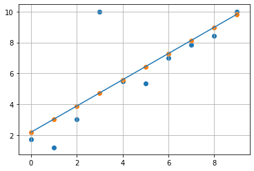

```python
y[3]=10
model = LinearRegression()
model.fit(np.array(x).reshape(-1,1), y)
model_result=model.predict(np.array(x).reshape(-1,1))
plt.grid(True)
plt.scatter(x,y)
plt.scatter(x,model_result)
plt.plot([x[0],x[-1]],[model_result[0],model_result[-1]])
plt.show()
```

Назад к Этапы

### Прореживание данных - выявление наиболее актуальных параметров

```python
df4 = pd.DataFrame({'SibSp':[0,0,1,2] , 'ParCh':[1,2,1,2]})
df4
```

|  | SibSp | ParCh |
| --- | --- | --- |
| 0 | 0 | 1 |
| 1 | 0 | 2 |
| 2 | 1 | 1 |
| 3 | 2 | 2 |

```python
df4['FamilySize']=df4['SibSp']+df4['ParCh']+1
df4
```

|  | SibSp | ParCh | FamilySize |
| --- | --- | --- | --- |
| 0 | 0 | 1 | 2 |
| 1 | 0 | 2 | 3 |
| 2 | 1 | 1 | 3 |
| 3 | 2 | 2 | 5 |

Назад к Этапы

### Проверка основных гипотез

```python
from scipy.stats import pearsonr
# тест корреляции Пирсона
corr, p = pearsonr(df['Visitors'], df['Income'])
print(corr, p)

# тест Стьюдента (различие образцов)
from scipy.stats import ttest_ind
stat, p = ttest_ind(df['Visitors'], df['Income'])
print(stat, p)
```

```
0.04820359204830521 0.9386490569396297
0.4058261123433027 0.6955080767399291
```

Назад к Этапы

### Разработка и применение начальных простых моделей

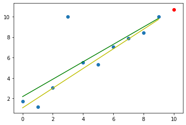

```python
gbc = LinearRegression()
gbc.fit(np.array(x).reshape((-1,1)), y)
plt.plot(x,gbc.predict(np.array(x).reshape(-1,1)),c='g')

gbc.fit(np.array(x[:3]+x[4:]).reshape((-1,1)), y[:3]+y[4:])
gbc_result=gbc.predict(np.array(x).reshape(-1,1))
plt.scatter(x,y)

plt.plot(x,gbc_result,c='y')

plt.scatter(10,gbc.predict(np.array([10]).reshape(-1,1)),c='r')

plt.show()
```

Назад к Этапы

# Домашнее задание

Провести разведочный анализ данных задачи "Titanic: Machine Learning from Disaster" (https://www.kaggle.com/c/titanic)

Ответить на вопросы теста